# 03_classification_extension_PedroAfonso_FINAL

## **Introduction**

During one of my many procrastinating moments, I went down a rabbit hole that somehow landed me in Svalbard, the arctic archipelago that belongs to Norway. I then decided to check the degree of urbanization of the archipelago according to Copernicus' Global Human Settlement Layer (GHSL), and what was my surprise when I found out that the vast majority of settlements were missing, most notably **Longyearbyen**, the capital and the largest settled area of Svalbard, where the famous Global Seed Vault is located.

[figure not shown]

I was frankly disappointed, but didn't think much more of it until I had to do OBIA's practical exam. Then, I had an idea! What if I created classification model trained on other Norwegian settlements to assess wether or not Longyearbyen was in fact undetectable?

I opened the GHSL website and found that the "featured content" was none other than a newly released [GHSL-Arctic](https://human-settlement.emergency.copernicus.eu/ghs_arctic2025.php) dataset! I couldn't believe it! Someone had noticed the poor coverage of the Arctic and had fixed it! I had just lost my project... Or so I thought...

As I checked the new dataset, I was happy to discover that Svalbard was still missing! In fact, the dataset doesn't include any human settlements north of 80° of latitude!

The following code is my adaptation of the `03_classification` Jupyter Notebook to this specific instant.

## **Setup**

Importing the necessary libraries

```python
import matplotlib.colors as mcolors
import matplotlib.pyplot as plt
import numpy as np
import pandas as pd
import geopandas as gpd
import rasterio
from rasterio.features import rasterize as feat_rasterize
from shapely.geometry import mapping

from scipy import stats
from skimage.color import label2rgb
from sklearn.ensemble import RandomForestClassifier
from skimage.feature import graycomatrix, graycoprops
from skimage.measure import regionprops_table
from skimage.segmentation import mark_boundaries, slic
from skimage.util import map_array
from sklearn.svm import SVC
from sklearn.preprocessing import StandardScaler
```

## **Data Preparation**

The GHSL website provides a zipfile with several shapefiles, each containing the cells corresponding to one of the 4 degrees of urbanization.

Considering the size of Longyearbyen, I focused on the smallest degree, Rural Clusters (RCs), which, by definition are settlements with at least 300 inhabitants per km<sup>2</sup> of permanent land and at least 500 people, characteristics which I think Longyearbyen respects.

```python
rc_shape = gpd.read_file("GHS_WUP_DEGURBA_E2025_GLOBE_R2025A_54009_1000_V1_0.zip",
                         layer='GHS_WUP_DEGURBA_E2025_GLOBE_R2025A_54009_1000_RC_V1_0')
```

```python
rc_shape
```

|  | ID_RC_G0 | UNLocID | AREA_km2 | POP_2025 | BU_km2_2025 | PWCentroidX | PWCentroidY | Unique_ID | geometry |
| --- | --- | --- | --- | --- | --- | --- | --- | --- | --- |
| 0 | 1 | 876 | 7 | 1888.455901 | 0.272887 | -1.736350e+07 | -1.644222e+06 | RC_1 | POLYGON ((-17362000 -1645000, -17363000 -16450... |
| 1 | 2 | 772 | 5 | 950.774888 | 0.012179 | -1.717143e+07 | -1.054307e+06 | RC_2 | POLYGON ((-17170000 -1055000, -17171000 -10550... |
| 2 | 3 | 882 | 8 | 1780.333170 | 0.213592 | -1.700950e+07 | -1.665500e+06 | RC_3 | MULTIPOLYGON (((-17005000 -1664000, -17006000 ... |
| 3 | 4 | 776 | 1 | 628.119092 | 0.035781 | -1.686850e+07 | -2.284500e+06 | RC_4 | POLYGON ((-16868000 -2285000, -16869000 -22850... |
| 4 | 5 | 16 | 2 | 711.384614 | 0.075298 | -1.678502e+07 | -1.762500e+06 | RC_5 | POLYGON ((-16784000 -1763000, -16786000 -17630... |
| ... | ... | ... | ... | ... | ... | ... | ... | ... | ... |
| 344316 | 344317 | 356 | 8 | 2914.931664 | 0.259803 | 9.193372e+06 | 1.483242e+06 | RC_344317 | POLYGON ((9194000 1484000, 9195000 1484000, 91... |
| 344317 | 344318 | 356 | 1 | 657.597469 | 0.030337 | 9.219500e+06 | 1.137500e+06 | RC_344318 | POLYGON ((9220000 1137000, 9219000 1137000, 92... |
| 344318 | 344319 | 356 | 8 | 4368.646821 | 0.210701 | 9.225500e+06 | 1.138500e+06 | RC_344319 | POLYGON ((9225000 1140000, 9226000 1140000, 92... |
| 344319 | 344320 | 356 | 2 | 815.620894 | 0.020981 | 9.272658e+06 | 1.025500e+06 | RC_344320 | POLYGON ((9274000 1025000, 9272000 1025000, 92... |
| 344320 | 344321 | 356 | 8 | 3051.952244 | 0.077766 | 9.318277e+06 | 9.926245e+05 | RC_344321 | POLYGON ((9318000 994000, 9319000 994000, 9319... |

344321 rows × 9 columns

The following map shows the only settlement identified in Svalbard by the GHSL project.

```python
rc_shape[rc_shape['UNLocID']==744].explore()
```

Make this Notebook Trusted to load map: File -> Trust Notebook

[interactive chart not shown]

The following map shows all the Rural Clusters in Norway identified by the GHSL project. I explored this map to locate areas with several rural cluster (and no larger clusters) to train my model.

```python
rc_shape[rc_shape['UNLocID']==578].explore()
```

Make this Notebook Trusted to load map: File -> Trust Notebook

[interactive chart not shown]

Using the Copernicus Browser, I got the tiff files for 3 training locations, all of them close to the beginning of Spring, which I believe is when the landscape looks the closest to the Svalbard Summer.

```python
# Training image A
B02_train = "2025-03-23-00_00_2025-03-23-23_59_Sentinel-2_L2A_B02_(Raw).tiff"  # Blue
B03_train = "2025-03-23-00_00_2025-03-23-23_59_Sentinel-2_L2A_B03_(Raw).tiff"  # Green
B04_train = "2025-03-23-00_00_2025-03-23-23_59_Sentinel-2_L2A_B04_(Raw).tiff"  # Red
B08_train = "2025-03-23-00_00_2025-03-23-23_59_Sentinel-2_L2A_B08_(Raw).tiff"  # NIR

# Training image B
B02_train_b = "2025-04-02-00_00_2025-04-02-23_59_Sentinel-2_L2A_B02_(Raw).tiff"
B03_train_b = "2025-04-02-00_00_2025-04-02-23_59_Sentinel-2_L2A_B03_(Raw).tiff"
B04_train_b = "2025-04-02-00_00_2025-04-02-23_59_Sentinel-2_L2A_B04_(Raw).tiff"
B08_train_b = "2025-04-02-00_00_2025-04-02-23_59_Sentinel-2_L2A_B08_(Raw).tiff"

# Training image C
B02_train_c = "2025-04-25-00_00_2025-04-25-23_59_Sentinel-2_L2A_B02_(Raw).tiff"
B03_train_c = "2025-04-25-00_00_2025-04-25-23_59_Sentinel-2_L2A_B03_(Raw).tiff"
B04_train_c = "2025-04-25-00_00_2025-04-25-23_59_Sentinel-2_L2A_B04_(Raw).tiff"
B08_train_c = "2025-04-25-00_00_2025-04-25-23_59_Sentinel-2_L2A_B08_(Raw).tiff"

# Inference image
B02_infer = "2024-08-01-00_00_2024-08-01-23_59_Sentinel-2_L2A_B02_(Raw).tiff"
B03_infer = "2024-08-01-00_00_2024-08-01-23_59_Sentinel-2_L2A_B03_(Raw).tiff"
B04_infer = "2024-08-01-00_00_2024-08-01-23_59_Sentinel-2_L2A_B04_(Raw).tiff"
B08_infer = "2024-08-01-00_00_2024-08-01-23_59_Sentinel-2_L2A_B08_(Raw).tiff"
```

```python
def read_and_stack(b02, b03, b04, b08):
    """
    Reads four Sentinel-2 single-band GeoTIFFs (B02 Blue, B03 Green, B04 Red, B08 NIR).
    Returns blue, green, red, nir, rgb, rgb_mean, ndvi, full_stack, profile.
    """
    def read_band(path):
        with rasterio.open(path) as src:
            return src.read(1).astype(float), src.profile

    red,   profile = read_band(b04)
    blue,  _       = read_band(b02)
    green, _       = read_band(b03)
    nir,   _       = read_band(b08)

    rgb        = np.dstack([red, green, blue])
    rgb_mean   = np.mean(rgb, axis=2)
    ndvi       = (nir - red) / (nir + red + 1e-6)
    full_stack = np.dstack([red, green, blue, nir, rgb_mean, ndvi])

    return blue, green, red, nir, rgb, rgb_mean, ndvi, full_stack, profile
```

```python
NDVI_THRS = 0.1

def plot_rgb_overview(rgb, ndvi, title_suffix=""):
    """Plot RGB, mean reflectance, and negative-NDVI."""
    rgb_disp = np.clip(rgb * 3, 0, 1)
    rgb_d_mean = np.mean(rgb_disp, axis=2)

    fig, axs = plt.subplots(ncols=3, figsize=(15, 5), constrained_layout=True)

    axs[0].imshow(rgb_disp)
    axs[0].set_title(f"Original RGB {title_suffix}")

    axs[1].imshow(rgb_d_mean, cmap='gray')
    axs[1].set_title("RGB Mean Reflectance")

    axs[2].imshow(np.where(ndvi < NDVI_THRS, ndvi, np.nan), cmap="plasma")
    axs[2].set_title("NDVI (negative only)")

    for ax in axs:
        ax.set_axis_off()
        #OR ax.axis("off")
    # plt.tight_layout() not needed because of "constrained_layout=True"
    plt.show()
```

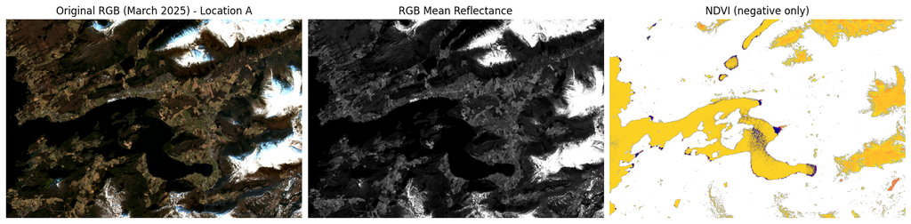

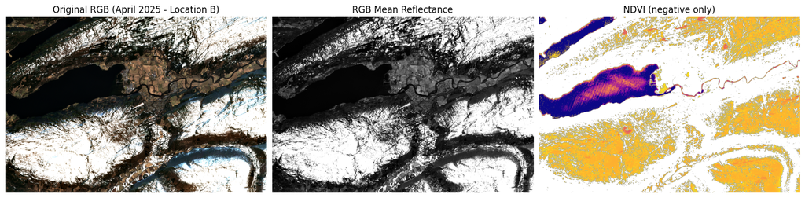

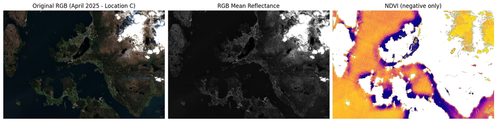

```python
blue, green, red, nir, rgb, rgb_mean, ndvi, full_stack, profile = read_and_stack(
    B02_train, B03_train, B04_train, B08_train
)
plot_rgb_overview(rgb, ndvi, title_suffix="(March 2025) - Location A")


blue_b, green_b, red_b, nir_b, rgb_b, rgb_mean_b, ndvi_b, full_stack_b, profile_b = read_and_stack(
    B02_train_b, B03_train_b, B04_train_b, B08_train_b
)
plot_rgb_overview(rgb_b, ndvi_b, title_suffix="(April 2025 - Location B)")


blue_c, green_c, red_c, nir_c, rgb_c, rgb_mean_c, ndvi_c, full_stack_c, profile_c = read_and_stack(
    B02_train_c, B03_train_c, B04_train_c, B08_train_c
)
plot_rgb_overview(rgb_c, ndvi_c, title_suffix="(April 2025 - Location C)")
```

## **Image Segmentation**

For the image segmentation, a relativelly slow number of segments was chosen with the goal of getting segments of the same aproximate size as the GHSL raster, thus preventing non-urban segments from being taken into account in the training.

```python
COMPACTNESS = 0.2
N_SEGMENTS  = 200

segments = slic(
    full_stack[:, :, :4],   # R, G, B, NIR
    n_segments=N_SEGMENTS,
    compactness=COMPACTNESS,
    start_label=1,
    channel_axis=-1,
)

segments_b = slic(
    full_stack_b[:, :, :4],
    n_segments=N_SEGMENTS, compactness=COMPACTNESS,
    start_label=1, channel_axis=-1,
)

segments_c = slic(
    full_stack_c[:, :, :4],
    n_segments=N_SEGMENTS, compactness=COMPACTNESS,
    start_label=1, channel_axis=-1,
)
```

```python
def plot_segmentation(rgb, segments, title_suffix=""):
    """Plot RGB, SLIC boundaries, and mean-colour segments."""
    fig, axs = plt.subplots(ncols=3, figsize=(15, 5), constrained_layout=True)
    rgb_disp = np.clip(rgb * 3, 0, 1)
    axs[0].imshow(rgb_disp)
    axs[0].set_title(f"Original RGB {title_suffix}")

    axs[1].imshow(mark_boundaries(rgb_disp, segments, color=(1, 0, 0), mode="thick"))
    axs[1].set_title(f"SLIC Boundaries ({N_SEGMENTS} segments)")

    axs[2].imshow(label2rgb(segments, rgb_disp, kind='avg'))
    axs[2].set_title("Mean RGB per Segment")

    for ax in axs:
        ax.set_axis_off()
    plt.show()
```

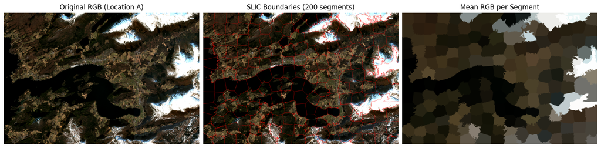

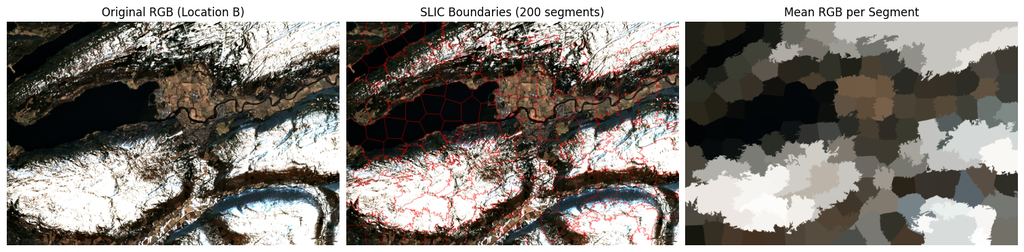

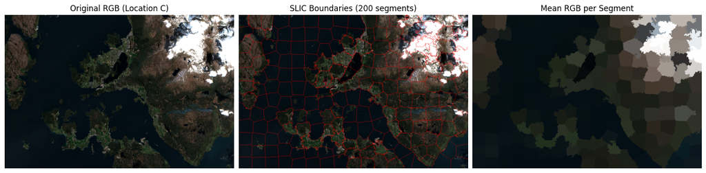

```python
plot_segmentation(rgb,   segments,   title_suffix="(Location A)")
plot_segmentation(rgb_b, segments_b, title_suffix="(Location B)")
plot_segmentation(rgb_c, segments_c, title_suffix="(Location C)")
```

## **Features Extraction**

In the original notebook, there were **Spectral Features**, **Shape Features** and **Textural Features**.

That being said, I don't think shape features are relevant in this situation, so I deleted them. On the other hand, I think texture is paramount to detect settlements, so I wanted to expand them. Thus, inspired by e-cognitions's texture features based on gray-level cooccurrence matrices (GLCM), I used AI to create the function `calc_glcm_feats`, that calculates the GLCM and some texture-related features from it. Afterwards, I simply updated the function `calc_all_feats`.

```python
# Define custom features
def std(regionmask, intensity_img):
    vals = intensity_img[regionmask]
    std = np.std(vals)
    return std

def entropy_ndvi(regionmask, intensity_img):
    vals = intensity_img[regionmask]
    arr = stats.relfreq(vals, 100, defaultreallimits=(-1,1))[0]
    return stats.entropy(arr)

def calc_glcm_feats(seg_arr, band, n_levels=32):
    """
    Compute GLCM texture features per segment from a single float band.
    The band is quantized to `n_levels` grey levels before GLCM computation.
    Features computed (averaged over 4 angles):
      contrast, dissimilarity, homogeneity, energy, correlation.
    Returns a DataFrame with one row per segment, indexed by label.
    """
    # Quantize float band to [0, n_levels-1] integers
    band_min, band_max = np.nanmin(band), np.nanmax(band)
    band_q = ((band - band_min) / (band_max - band_min + 1e-6) * (n_levels - 1)).astype(np.uint8)

    PROPS    = ["contrast", "dissimilarity", "homogeneity", "energy", "correlation"]
    ANGLES   = [0, np.pi / 4, np.pi / 2, 3 * np.pi / 4]
    records  = []

    for lbl in np.unique(seg_arr):
        mask = seg_arr == lbl
        rows, cols = np.where(mask)
        # Extract the bounding-box patch and re-apply the segment mask
        r0, r1 = rows.min(), rows.max() + 1
        c0, c1 = cols.min(), cols.max() + 1
        patch      = band_q[r0:r1, c0:c1]
        patch_mask = mask[r0:r1, c0:c1]
        # Zero-out pixels outside the segment so they don't influence the GLCM
        patch_masked = patch * patch_mask

        glcm = graycomatrix(
            patch_masked,
            distances=[1],
            angles=ANGLES,
            levels=n_levels,
            symmetric=True,
            normed=True,
        )
        row = {"label": lbl}
        for prop in PROPS:
            # Average across the 4 directions
            row[f"glcm_{prop}"] = graycoprops(glcm, prop).mean()
        records.append(row)

    return pd.DataFrame(records).set_index("label")

# Calculate set of various features for each segment
def calc_all_feats(seg_arr, img_arr):
    spectral_feats = pd.DataFrame(
        regionprops_table(
            label_image = seg_arr,
            intensity_image = img_arr,
            properties = ["label", "intensity_mean"],
            extra_properties=(std,)
        )
    )

    glcm_ndvi = calc_glcm_feats(seg_arr, img_arr[:, :, 5])  # ndvi
    #glcm_ndvi = glcm_ndvi.add_prefix("ndvi_")

    all_feats = pd.concat([spectral_feats, glcm_ndvi.reset_index(drop=True)], axis=1)

    return all_feats

all_feats_df = calc_all_feats(segments, full_stack).rename(columns={"label": "indx"})
display(all_feats_df)

all_feats_dfb = calc_all_feats(segments_b, full_stack_b).rename(columns={"label": "indx"})
display(all_feats_dfb)

all_feats_dfc = calc_all_feats(segments_c, full_stack_c).rename(columns={"label": "indx"})
display(all_feats_dfc)
```

|  | indx | intensity_mean-0 | intensity_mean-1 | intensity_mean-2 | intensity_mean-3 | intensity_mean-4 | intensity_mean-5 | std-0 | std-1 | std-2 | std-3 | std-4 | std-5 | glcm_contrast | glcm_dissimilarity | glcm_homogeneity | glcm_energy | glcm_correlation |
| --- | --- | --- | --- | --- | --- | --- | --- | --- | --- | --- | --- | --- | --- | --- | --- | --- | --- | --- |
| 0 | 1 | 0.071640 | 0.052787 | 0.029106 | 0.241990 | 0.051178 | 0.566610 | 0.037230 | 0.030309 | 0.021343 | 0.070871 | 0.029284 | 0.136021 | 5.451725 | 0.737579 | 0.750174 | 0.262824 | 0.901578 |
| 1 | 2 | 0.064042 | 0.043543 | 0.024263 | 0.221678 | 0.043949 | 0.553098 | 0.011181 | 0.008178 | 0.006266 | 0.025226 | 0.008236 | 0.045069 | 7.840038 | 0.588701 | 0.855321 | 0.457301 | 0.901150 |
| 2 | 3 | 0.048379 | 0.033870 | 0.017354 | 0.184263 | 0.033201 | 0.536546 | 0.023256 | 0.015747 | 0.010597 | 0.072429 | 0.016319 | 0.277504 | 14.174282 | 1.078429 | 0.780053 | 0.307278 | 0.900750 |
| 3 | 4 | 0.074841 | 0.058074 | 0.031441 | 0.253538 | 0.054785 | 0.560902 | 0.038124 | 0.032227 | 0.022139 | 0.089632 | 0.030469 | 0.148008 | 11.069375 | 0.880109 | 0.779393 | 0.274161 | 0.938989 |
| 4 | 5 | 0.042044 | 0.037472 | 0.022710 | 0.188383 | 0.034075 | 0.705444 | 0.043971 | 0.043945 | 0.044740 | 0.106697 | 0.042923 | 0.208738 | 11.699771 | 0.963576 | 0.772969 | 0.305575 | 0.956395 |
| ... | ... | ... | ... | ... | ... | ... | ... | ... | ... | ... | ... | ... | ... | ... | ... | ... | ... | ... |
| 183 | 184 | 0.032865 | 0.029869 | 0.014336 | 0.185172 | 0.025690 | 0.733661 | 0.031528 | 0.028062 | 0.024633 | 0.094294 | 0.027387 | 0.138322 | 14.107051 | 1.008230 | 0.767309 | 0.279035 | 0.944915 |
| 184 | 185 | 0.061046 | 0.053822 | 0.032451 | 0.213946 | 0.049106 | 0.591433 | 0.045730 | 0.037407 | 0.033315 | 0.076217 | 0.038274 | 0.240977 | 13.421409 | 1.154545 | 0.727196 | 0.304916 | 0.948953 |
| 185 | 186 | 0.197120 | 0.200688 | 0.199302 | 0.285928 | 0.199036 | 0.382574 | 0.236477 | 0.244044 | 0.254861 | 0.205644 | 0.244339 | 0.300363 | 6.950121 | 0.719906 | 0.820526 | 0.544054 | 0.970572 |
| 186 | 187 | 0.149632 | 0.143388 | 0.131838 | 0.302950 | 0.141619 | 0.384600 | 0.121546 | 0.124361 | 0.134049 | 0.157620 | 0.124565 | 0.194233 | 14.324812 | 1.296180 | 0.689059 | 0.270736 | 0.921721 |
| 187 | 188 | 0.139780 | 0.137266 | 0.130437 | 0.283210 | 0.135828 | 0.419480 | 0.116515 | 0.116290 | 0.123110 | 0.101638 | 0.117860 | 0.235025 | 14.828511 | 1.244614 | 0.696907 | 0.271513 | 0.925740 |

188 rows × 18 columns

|  | indx | intensity_mean-0 | intensity_mean-1 | intensity_mean-2 | intensity_mean-3 | intensity_mean-4 | intensity_mean-5 | std-0 | std-1 | std-2 | std-3 | std-4 | std-5 | glcm_contrast | glcm_dissimilarity | glcm_homogeneity | glcm_energy | glcm_correlation |
| --- | --- | --- | --- | --- | --- | --- | --- | --- | --- | --- | --- | --- | --- | --- | --- | --- | --- | --- |
| 0 | 1 | 0.040683 | 0.040316 | 0.029939 | 0.140780 | 0.036979 | 0.303392 | 0.045674 | 0.037080 | 0.025620 | 0.112640 | 0.035834 | 0.613515 | 13.924187 | 1.102956 | 0.765986 | 0.318090 | 0.946186 |
| 1 | 2 | 0.056307 | 0.052449 | 0.036187 | 0.205401 | 0.048315 | 0.599618 | 0.042175 | 0.033301 | 0.024456 | 0.082319 | 0.032858 | 0.149936 | 10.380624 | 0.786067 | 0.808533 | 0.321097 | 0.958390 |
| 2 | 3 | 0.049596 | 0.044437 | 0.030381 | 0.183224 | 0.041471 | 0.603113 | 0.035681 | 0.028795 | 0.023388 | 0.060694 | 0.029011 | 0.171437 | 10.029002 | 0.808563 | 0.798883 | 0.349245 | 0.963234 |
| 3 | 4 | 0.009939 | 0.011591 | 0.011218 | 0.031605 | 0.010916 | -0.484441 | 0.018631 | 0.015999 | 0.012486 | 0.063544 | 0.015461 | 0.680750 | 10.976221 | 0.949948 | 0.820357 | 0.672592 | 0.937595 |
| 4 | 5 | 0.032757 | 0.036561 | 0.030094 | 0.119933 | 0.033137 | 0.055771 | 0.060384 | 0.059971 | 0.058504 | 0.117896 | 0.059246 | 0.757562 | 19.805024 | 1.324068 | 0.799356 | 0.543871 | 0.930963 |
| ... | ... | ... | ... | ... | ... | ... | ... | ... | ... | ... | ... | ... | ... | ... | ... | ... | ... | ... |
| 127 | 128 | 0.116532 | 0.120229 | 0.114426 | 0.211685 | 0.117063 | 0.391008 | 0.145178 | 0.149220 | 0.156098 | 0.119935 | 0.149592 | 0.258354 | 6.093505 | 0.737889 | 0.798760 | 0.487208 | 0.974406 |
| 128 | 129 | 0.091154 | 0.073181 | 0.054508 | 0.204344 | 0.072948 | 0.477542 | 0.097200 | 0.097248 | 0.097600 | 0.080541 | 0.096933 | 0.211019 | 8.554255 | 0.959591 | 0.744550 | 0.292816 | 0.960137 |
| 129 | 130 | 0.028163 | 0.030655 | 0.020437 | 0.192273 | 0.026419 | 0.761813 | 0.025943 | 0.021942 | 0.021197 | 0.047839 | 0.022599 | 0.147332 | 8.180814 | 0.844616 | 0.740158 | 0.244156 | 0.920213 |
| 130 | 131 | 0.868136 | 0.885828 | 0.887493 | 0.746162 | 0.880486 | -0.073232 | 0.145006 | 0.149048 | 0.151669 | 0.108680 | 0.147934 | 0.025732 | 6.395790 | 0.488429 | 0.946890 | 0.647035 | 0.934632 |
| 131 | 132 | 0.088343 | 0.065940 | 0.045279 | 0.215221 | 0.066520 | 0.481556 | 0.067666 | 0.063336 | 0.061399 | 0.064789 | 0.063427 | 0.202095 | 8.994555 | 1.106779 | 0.696177 | 0.215149 | 0.942035 |

132 rows × 18 columns

|  | indx | intensity_mean-0 | intensity_mean-1 | intensity_mean-2 | intensity_mean-3 | intensity_mean-4 | intensity_mean-5 | std-0 | std-1 | std-2 | std-3 | std-4 | std-5 | glcm_contrast | glcm_dissimilarity | glcm_homogeneity | glcm_energy | glcm_correlation |
| --- | --- | --- | --- | --- | --- | --- | --- | --- | --- | --- | --- | --- | --- | --- | --- | --- | --- | --- |
| 0 | 1 | 0.016637 | 0.025278 | 0.027147 | 0.056022 | 0.023020 | 0.108206 | 0.019296 | 0.012977 | 0.009075 | 0.076907 | 0.013254 | 0.409721 | 11.793564 | 1.364605 | 0.635602 | 0.215959 | 0.923380 |
| 1 | 2 | 0.069913 | 0.057683 | 0.047698 | 0.181016 | 0.058431 | 0.453877 | 0.022906 | 0.016113 | 0.015306 | 0.029184 | 0.017907 | 0.121274 | 10.815736 | 0.935726 | 0.758733 | 0.281217 | 0.915856 |
| 2 | 3 | 0.080284 | 0.070108 | 0.057321 | 0.204387 | 0.069238 | 0.442502 | 0.029267 | 0.024818 | 0.025919 | 0.044272 | 0.025723 | 0.146209 | 10.065181 | 0.862597 | 0.777439 | 0.282701 | 0.935144 |
| 3 | 4 | 0.007666 | 0.021657 | 0.028699 | 0.006080 | 0.019340 | -0.326074 | 0.013616 | 0.012121 | 0.011215 | 0.018798 | 0.012094 | 0.284224 | 7.476368 | 1.563027 | 0.532214 | 0.183244 | 0.869041 |
| 4 | 5 | 0.007986 | 0.022393 | 0.029691 | 0.006350 | 0.020023 | -0.179116 | 0.011343 | 0.011281 | 0.011388 | 0.013526 | 0.011128 | 0.114820 | 3.622412 | 1.203186 | 0.557541 | 0.194046 | 0.845637 |
| ... | ... | ... | ... | ... | ... | ... | ... | ... | ... | ... | ... | ... | ... | ... | ... | ... | ... | ... |
| 194 | 195 | 0.037315 | 0.042579 | 0.032033 | 0.213036 | 0.037309 | 0.705778 | 0.016590 | 0.014480 | 0.009608 | 0.054728 | 0.013154 | 0.090292 | 10.182391 | 0.688629 | 0.839204 | 0.385915 | 0.965705 |
| 195 | 196 | 0.006306 | 0.017024 | 0.025197 | 0.005850 | 0.016176 | -0.038284 | 0.000813 | 0.001002 | 0.001289 | 0.000833 | 0.000765 | 0.072839 | 4.129788 | 1.043011 | 0.621122 | 0.249697 | 0.891336 |
| 196 | 197 | 0.011095 | 0.023204 | 0.030226 | 0.009686 | 0.021508 | -0.068352 | 0.001608 | 0.001895 | 0.002004 | 0.001479 | 0.001692 | 0.046489 | 3.220775 | 0.746875 | 0.718577 | 0.386312 | 0.674464 |
| 197 | 198 | 0.006460 | 0.017780 | 0.025871 | 0.005701 | 0.016704 | -0.063079 | 0.000816 | 0.001018 | 0.001321 | 0.000799 | 0.000778 | 0.074421 | 3.952067 | 1.030822 | 0.624372 | 0.249532 | 0.908164 |
| 198 | 199 | 0.030258 | 0.030650 | 0.025012 | 0.138290 | 0.028640 | 0.673509 | 0.023077 | 0.017548 | 0.013081 | 0.071794 | 0.017708 | 0.137887 | 14.792166 | 1.087593 | 0.736914 | 0.241177 | 0.920199 |

199 rows × 18 columns

## **Image Classification**

### **Labeling**

With the help of AI, I created the functions `rasterize_rc` and `label_segments` to turn the RC polygons into a raster that could then be used in the labeling process.

Furthermore, I completely excluded from the training low NDVI segments that had been identified as Rural Clusters (to, hopefully, exclude water segments erronesouly labeled), and also segments that intercepted the RC polygons, but where less than 50% of their area was included (since this would, in my opinion, introduce ambiguity).

```python
def rasterize_rc(rc_shapefile, profile, un_loc_id):
    """
    Burn a GeoDataFrame of RC polygons onto the raster grid defined by `profile`.
    Returns a binary uint8 array: 1 inside an RC polygon, 0 elsewhere.
    """
    rc_filtered = rc_shapefile[rc_shapefile['UNLocID'] == un_loc_id].copy().to_crs(profile['crs'])
    burn_shapes = [
        (mapping(geom), 1)
        for geom in rc_filtered.geometry
        if geom is not None and not geom.is_empty
    ]
    return feat_rasterize(
        burn_shapes,
        out_shape=(profile['height'], profile['width']),
        transform=profile['transform'],
        fill=0,
        dtype='uint8',
    )

def label_segments(segments, rc_raster, ndvi, rc_threshold=0.5, ndvi_min=NDVI_THRS):
    """
    Label segments for training with strict overlap rules to avoid ambiguity:
      - class 1 (RC)     : >= `rc_threshold` of pixels inside an RC polygon
                           AND mean NDVI >= `ndvi_min`
      - class 0 (non-RC) : exactly 0% of pixels inside an RC polygon
      - excluded (NaN)   : anything in between (ambiguous border segments)
    Returns a dict {segment_label: class}, with ambiguous segments omitted.
    """
    result = {}
    for lbl in np.unique(segments):
        mask     = (segments == lbl)
        rc_frac  = rc_raster[mask].mean()
        if rc_frac >= rc_threshold and ndvi[mask].mean() >= ndvi_min:
                result[lbl] = 1
        elif rc_frac == 0.0:
            result[lbl] = 0
        # else: ambiguous — omit from training
    return result

rc_raster = rasterize_rc(rc_shape, profile, 578)
rc_raster_b = rasterize_rc(rc_shape, profile_b, 578)
rc_raster_c = rasterize_rc(rc_shape, profile_c, 578)

seg_class_map = label_segments(segments, rc_raster, ndvi)
all_feats_df["class"] = all_feats_df["indx"].map(seg_class_map)

seg_class_map_b = label_segments(segments_b, rc_raster_b, ndvi_b)
all_feats_dfb["class"] = all_feats_dfb["indx"].map(seg_class_map_b)

seg_class_map_c = label_segments(segments_c, rc_raster_c, ndvi_c)
all_feats_dfc["class"] = all_feats_dfc["indx"].map(seg_class_map_c)
```

```python
print(f"  Rural cluster segments : {(all_feats_df['class'] == 1).sum()}")
print(f"  Other segments         : {(all_feats_df['class'] == 0).sum()}")
print(f"  Excluded (ambiguous)   : {(np.isnan(all_feats_df['class'])).sum()}")
print(f"  Missing                : {len(set(np.unique(segments)) - set(all_feats_df["indx"]))}")

print('\n')

print(f"  Rural cluster segments : {(all_feats_dfb['class'] == 1).sum()}")
print(f"  Other segments         : {(all_feats_dfb['class'] == 0).sum()}")
print(f"  Excluded (ambiguous)   : {(np.isnan(all_feats_df['class'])).sum()}")
print(f"  Missing                : {len(set(np.unique(segments_b)) - set(all_feats_dfb["indx"]))}")

print('\n')

print(f"  Rural cluster segments : {(all_feats_dfc['class'] == 1).sum()}")
print(f"  Other segments         : {(all_feats_dfc['class'] == 0).sum()}")
print(f"  Excluded (ambiguous)   : {(np.isnan(all_feats_df['class'])).sum()}")
print(f"  Missing                : {len(set(np.unique(segments_c)) - set(all_feats_dfc["indx"]))}")
```

```
  Rural cluster segments : 7
  Other segments         : 166
  Excluded (ambiguous)   : 15
  Missing                : 0


  Rural cluster segments : 6
  Other segments         : 114
  Excluded (ambiguous)   : 15
  Missing                : 0


  Rural cluster segments : 5
  Other segments         : 169
  Excluded (ambiguous)   : 15
  Missing                : 0
```

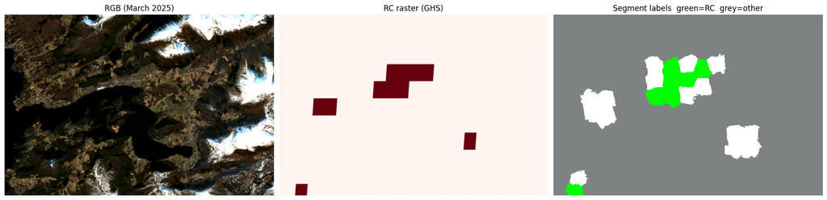

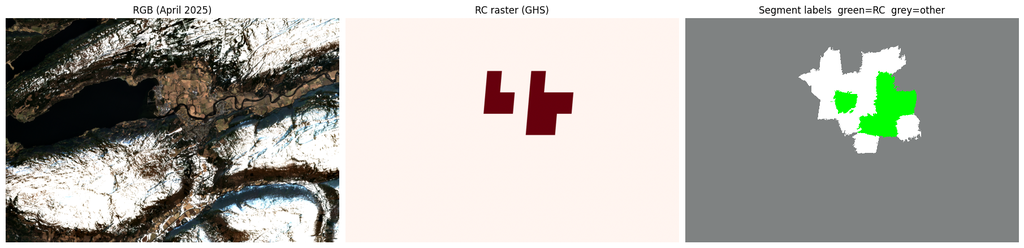

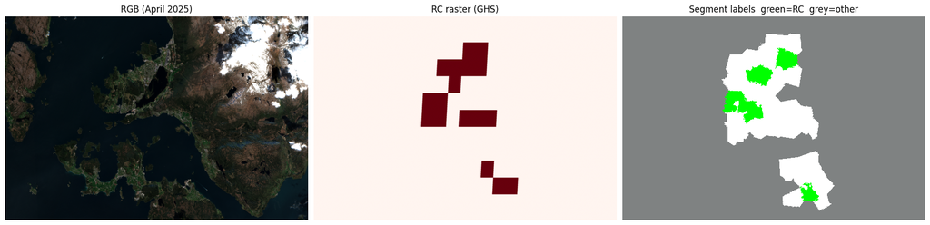

```python
binary_cmap = mcolors.ListedColormap(['#7f8282', '#00008b', '#00FF00'])

def plot_labels(rgb, rc_raster, segments, feats_df, title_suffix=""):
    """Plot RGB, RC Raster, and segment labels."""
    rgb_disp = np.clip(rgb * 3, 0, 1)
    mapped = map_array(
        segments,
        np.array(feats_df["indx"]),
        np.array(feats_df["class"]),
    )

    fig, axs = plt.subplots(1, 3, figsize=(18, 6), constrained_layout=True)
    axs[0].imshow(rgb_disp)
    axs[0].set_title(f"RGB {title_suffix}")

    axs[1].imshow(rc_raster, cmap="Reds")
    axs[1].set_title("RC raster (GHS)")

    axs[2].imshow(mapped, cmap=binary_cmap, interpolation="nearest")
    axs[2].set_title("Segment labels  green=RC  grey=other")

    for ax in axs:
        ax.set_axis_off()
    plt.show()
    return mapped

mapped_labels   = plot_labels(rgb,   rc_raster, segments,   all_feats_df,  title_suffix="(March 2025)")
mapped_labels_b = plot_labels(rgb_b, rc_raster_b, segments_b, all_feats_dfb, title_suffix="(April 2025)")
mapped_labels_c = plot_labels(rgb_c, rc_raster_c, segments_c, all_feats_dfc, title_suffix="(April 2025)")
```

```python
all_feats_final = pd.concat([all_feats_df.drop(columns="indx"),
                             all_feats_dfb.drop(columns="indx"),
                             all_feats_dfc.drop(columns="indx")]).dropna(subset=["class"]).copy()

all_feats_final["class"] = all_feats_final["class"].astype(int)
```

#### **Train Random Forest Classifier**

```python
feature_cols = [c for c in all_feats_final.columns if c !="class"]
X = all_feats_final[feature_cols]
y = all_feats_final["class"]

# Train the Random Forest Classifier using the entire dataset
rfc_clf = RandomForestClassifier(n_estimators=100, oob_score=True, random_state=42)
rfc_clf.fit(X, y)

# Evaluate the model using OOB score
print("OOB Score:", rfc_clf.oob_score_)
```

```
OOB Score: 0.9635974304068522
```

```python
feat_imp = pd.Series(rfc_clf.feature_importances_, index=feature_cols).sort_values(ascending=False)
print("Top features:\n", feat_imp.head(5).to_string())
```

```
Top features:
 std-2                 0.090977
glcm_dissimilarity    0.087306
intensity_mean-1      0.083919
intensity_mean-4      0.076454
glcm_homogeneity      0.075908
```

I was happy to see that two of my GLCM features were in the Top 5 more important for the model. That being said, the actual results weren't as motivating...

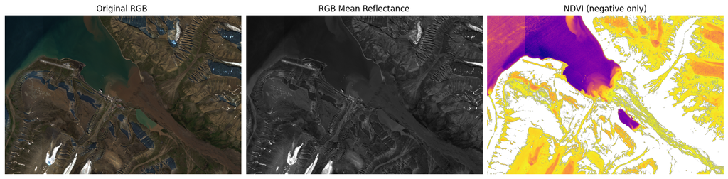

```python
blue_i, green_i, red_i, nir_i, rgb_i, rgb_mean_i, ndvi_i, full_stack_i, profile_i = read_and_stack(
    B02_infer, B03_infer, B04_infer, B08_infer
)
plot_rgb_overview(rgb_i, ndvi_i)
```

```
Running SLIC…
Extracting features…
```

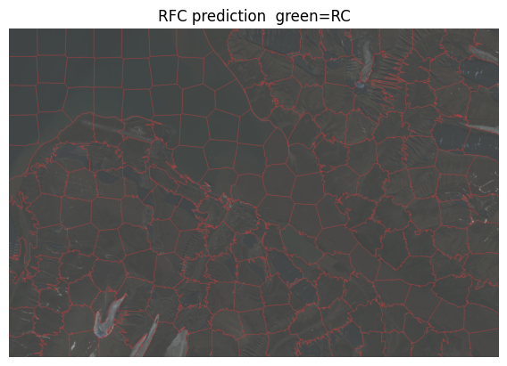

```python
print("Running SLIC…")
segments_i = slic(
    full_stack_i[:, :, :4],
    n_segments=N_SEGMENTS, compactness=COMPACTNESS,
    start_label=1, channel_axis=-1,
)

print("Extracting features…")
feats_i = calc_all_feats(segments_i, full_stack_i).rename(columns={"label": "indx"})
feats_i["rfc_pred"] = rfc_clf.predict(feats_i[feature_cols])

seg_labels  = np.array(feats_i["indx"])

mapped_infer = map_array(segments_i, seg_labels, np.array(feats_i["rfc_pred"]))

fig, ax = plt.subplots(figsize=(6, 4), constrained_layout=True)

ax.imshow(mark_boundaries(rgb_i, segments_i, color=(1, 0, 0), mode="thick"))
ax.imshow(mapped_infer, cmap=binary_cmap, alpha=0.5, interpolation="nearest")
ax.set_title("RFC prediction  green=RC")

ax.set_axis_off()
plt.show()
```

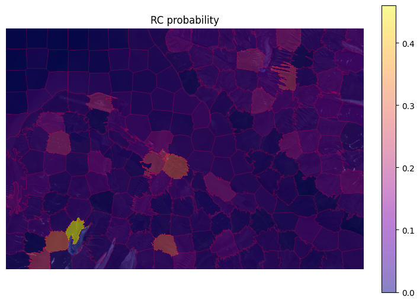

```python
feats_i["rfc_prob"] = rfc_clf.predict_proba(feats_i[feature_cols])[:, 1]

mapped_prob = map_array(segments_i, seg_labels, np.array(feats_i["rfc_prob"]))

vmax = feats_i["rfc_prob"].max()

fig, ax = plt.subplots(figsize=(7, 5), constrained_layout=True)
ax.imshow(mark_boundaries(rgb_i, segments_i, color=(1, 0, 0), mode="thick"))
prob_plot = ax.imshow(mapped_prob, cmap="plasma", alpha=0.5, vmin=0, vmax=vmax, interpolation="nearest")
plt.colorbar(prob_plot, ax=ax)
ax.set_title("RC probability")
ax.axis("off")
plt.show()
```

This probability heat map was especially worrying, considering the actual settlement segments aren't the ones with the highest probability!

#### **Train Suport Vector Machines**

Once again, taking inspiration from e-Cognition, I decided to try and implement a classifier based on Suport Vector Machines (SVMs), which always yielded better results on my other assignements. The largest difference when compared to setting up the Random Forest Classifier is that SVMs don't [«perform well when the input numerical attributes have very different scales»](https://shashwatwork.github.io/assets/files/ml_ebook.pdf) , which is why I had to apply some feature scaling.

```python
scaler = StandardScaler()
X_scaled = scaler.fit_transform(X).copy()

# Instantiate the classifier model
svm_classifier = SVC(probability=True, class_weight="balanced", random_state=42)
# Fit the model with the training data
svm_classifier.fit(X_scaled, y)
```

```
SVC(class_weight='balanced', probability=True, random_state=42)
```

```python
# Scale new data the same way
X_new_scaled = scaler.transform(feats_i[feature_cols])

# Predict
feats_i["svc_pred"] = svm_classifier.predict(X_new_scaled)
feats_i["svc_prob"] = svm_classifier.predict_proba(X_new_scaled)[:, 1]
```

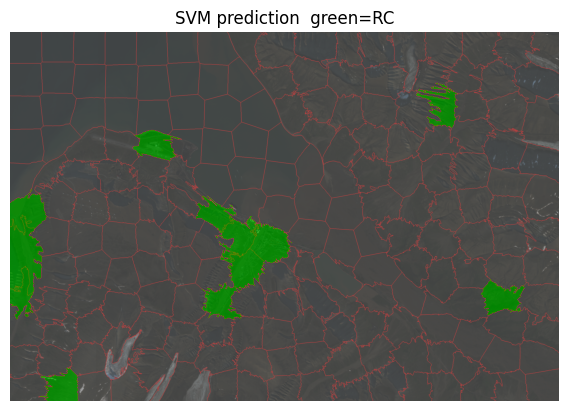

```python
mapped_infer = map_array(segments_i, seg_labels, np.array(feats_i["svc_pred"]))

fig, ax = plt.subplots(figsize=(6, 4), constrained_layout=True)

ax.imshow(mark_boundaries(rgb_i, segments_i, color=(1, 0, 0), mode="thick"))
ax.imshow(mapped_infer, cmap=binary_cmap, alpha=0.5, interpolation="nearest")
ax.set_title("SVM prediction  green=RC")

ax.set_axis_off()
plt.show()
```

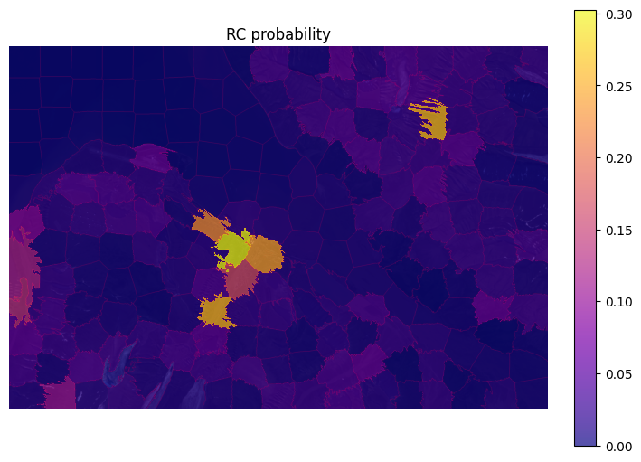

```python
mapped_prob = map_array(segments_i, seg_labels, np.array(feats_i["svc_prob"]))

vmax = feats_i["svc_prob"].max()

fig, ax = plt.subplots(figsize=(7, 5), constrained_layout=True)
ax.imshow(mark_boundaries(rgb_i, segments_i, color=(1, 0, 0), mode="thick"))
prob_plot = ax.imshow(mapped_prob, cmap="plasma", alpha=0.7, vmin=0, vmax=vmax, interpolation="nearest")
plt.colorbar(prob_plot, ax=ax)
ax.set_title("RC probability")
ax.axis("off")
plt.show()
```

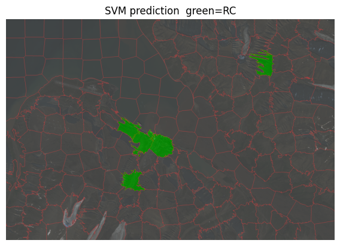

```python
feats_i["svc_pred2"] = (feats_i["svc_prob"] > 0.2).astype(int)

mapped_infer2 = map_array(segments_i, seg_labels, np.array(feats_i["svc_pred2"]))

fig, ax = plt.subplots(figsize=(6, 4), constrained_layout=True)

ax.imshow(mark_boundaries(rgb_i, segments_i, color=(1, 0, 0), mode="thick"))
ax.imshow(mapped_infer2, cmap=binary_cmap, alpha=0.5, interpolation="nearest")
ax.set_title("SVM prediction  green=RC")

ax.set_axis_off()
plt.show()
```